```python
from IPython.display import HTML

HTML('''<script>
code_show=true;
function code_toggle() {
 if (code_show){
 $('div.input').hide();
 } else {
 $('div.input').show();
 }
 code_show = !code_show
}
$( document ).ready(code_toggle);
</script>
<form action="javascript:code_toggle()"><input type="submit" value="Click here to show/hide the code."></form>''')
```

# Analysis of the Berlin Airbnb market in 2018

Authors: Valerio Paolicelli, Matteo Antonio Senese

Course: Data Spaces, a.y. 2018/19

University: Politecnico di Torino

- 1. Dataset analysis
  - 1.1. Structure
  - 1.2. Potential income
  - 1.3. Neighbourhood analysis
  - 1.4. Type of room analysis
- 2. Data preparation
  - 2.1. Unuseful columns removal
  - 2.2. Data standardize
  - 2.3. PCA
- 3. Classification
  - 3.1. SVM
  - 3.2. Decision trees
  - 3.3. Random forest
  - 3.4. KNN
- 4. Regression
  - 4.1. Linear regression
  - 4.2. Regression tree
  - 4.3. Random forest regression
- 5. Final considerations

Airbnb is one of the most famous online marketplace that allows users to accommodate guests with short-term lodging and tourism-related activities all over the world. The company was founded in August 2008 by Brian Chesky, Nathan Blecharczyk and Joe Gebbia in San Francisco, CA. The idea was born by the difficulties of Chesky and Gebbia, at this time students in San Francisco, to pay the house rent. This situation bring them to put an air mattress in their living room and turning it into a bed and breakfast to "make a few bucks".

Over time the company has evolved and has reached 1 billion dollar of revenue in the third quarter of 2018.

The company offers several different packets beyond its core component such as experiences, Airbnb Plus, Airbnb Collections, Niido and Natiivo.

In the proposed work we perfomed an analysis of the Airbnb market since november 2018 in city of Berlin which is one of the most attractive city in Europe. The work is divided in four core parts. We firstly performed an analysis of the dataset in order to understand its structure and some important aspects of the AirBnb market in the city, after this the unsupervised method PCA for dimensionality reduction is performed. Then, we moved to supervised methods by providing several classifiers which, given some features like the district, the price etc., have to predict the correspondent type of room. Lastly a some regressors are used to predict the price of the accomodation given the other features.

The Berlin Airbnb dataset is made available by Airbnb at the following URL: http://insideairbnb.com/get-the-data.html

The analyzed datased is the one referring to 07 November 2018 as compiled date. More recent data are also available.

## 1 Dataset analysis

### 1.1 Structure

The dataset shows the following structure:

```python
import numpy as np
import pandas as pd
import matplotlib.pyplot as plt
from sklearn.preprocessing import StandardScaler
from sklearn.decomposition import PCA
from sklearn.linear_model import LinearRegression
import math
#regression
from sklearn.linear_model import Ridge
from sklearn.model_selection import KFold, cross_val_score
from IPython.display import display, Markdown, Latex
from sklearn.feature_selection import f_regression, mutual_info_regression
from sklearn import feature_selection

# Tree regressors
from sklearn.tree import DecisionTreeRegressor
from sklearn import tree
from sklearn.ensemble import RandomForestRegressor


# Classifier imports
from sklearn.model_selection import train_test_split
from sklearn.model_selection import GridSearchCV
from sklearn.model_selection import learning_curve
from sklearn import svm
from sklearn.svm import SVR
from sklearn.neighbors import KNeighborsClassifier
from sklearn.tree import DecisionTreeClassifier
from sklearn.tree import export_graphviz
from sklearn.externals.six import StringIO
from IPython.display import Image
import pydotplus
from sklearn.ensemble import RandomForestClassifier
from sklearn.metrics import classification_report, confusion_matrix, f1_score





# style of the plots
plt.style.use('seaborn-pastel')
# seed for repetability of results
_SEED = 2567
```

```python
berlin_data = pd.read_csv('berlin-airbnb-data/listings.csv')
berlin_data.head()
```

|  | id | name | host_id | host_name | neighbourhood_group | neighbourhood | latitude | longitude | room_type | price | minimum_nights | number_of_reviews | last_review | reviews_per_month | calculated_host_listings_count | availability_365 |
| --- | --- | --- | --- | --- | --- | --- | --- | --- | --- | --- | --- | --- | --- | --- | --- | --- |
| 0 | 2015 | Berlin-Mitte Value! Quiet courtyard/very central | 2217 | Ian | Mitte | Brunnenstr. Süd | 52.534537 | 13.402557 | Entire home/apt | 60 | 4 | 118 | 2018-10-28 | 3.76 | 4 | 141 |
| 1 | 2695 | Prenzlauer Berg close to Mauerpark | 2986 | Michael | Pankow | Prenzlauer Berg Nordwest | 52.548513 | 13.404553 | Private room | 17 | 2 | 6 | 2018-10-01 | 1.42 | 1 | 0 |
| 2 | 3176 | Fabulous Flat in great Location | 3718 | Britta | Pankow | Prenzlauer Berg Südwest | 52.534996 | 13.417579 | Entire home/apt | 90 | 62 | 143 | 2017-03-20 | 1.25 | 1 | 220 |
| 3 | 3309 | BerlinSpot Schöneberg near KaDeWe | 4108 | Jana | Tempelhof - Schöneberg | Schöneberg-Nord | 52.498855 | 13.349065 | Private room | 26 | 5 | 25 | 2018-08-16 | 0.39 | 1 | 297 |
| 4 | 7071 | BrightRoom with sunny greenview! | 17391 | Bright | Pankow | Helmholtzplatz | 52.543157 | 13.415091 | Private room | 42 | 2 | 197 | 2018-11-04 | 1.75 | 1 | 26 |

The shape of the original dataset is:

```
- 22552 rows
- 16 columns
```

```python
%%capture
berlin_data.shape
```

While the shape of the dataset after the removal of the rows containing NaN is:

```
- 18587 rows
- 16 columns
```

The list of features with the correspondant type:

```python
#data['name'] = data.name.astype('str')
berlin_data.dtypes
```

```
id                                  int64
name                               object
host_id                             int64
host_name                          object
neighbourhood_group                object
neighbourhood                      object
latitude                          float64
longitude                         float64
room_type                          object
price                               int64
minimum_nights                      int64
number_of_reviews                   int64
last_review                        object
reviews_per_month                 float64
calculated_host_listings_count      int64
availability_365                    int64
dtype: object
```

(Pandas references string by holding the reference to its object. So the object listed above are strings)  
In the table below we have reported some important statistics about some selected features. The 25%, 50% and 75% percentiles are called respectively the first quartile, the median and the third quartile. Percentile is a number where a certain percentage of scores fall below that number.

```python
berlin_data[['price', 'minimum_nights', 'number_of_reviews', 'reviews_per_month', 'calculated_host_listings_count',
      'availability_365']]\
.describe()
```

|  | price | minimum_nights | number_of_reviews | reviews_per_month | calculated_host_listings_count | availability_365 |
| --- | --- | --- | --- | --- | --- | --- |
| count | 22552.000000 | 22552.000000 | 22552.000000 | 18638.000000 | 22552.000000 | 22552.000000 |
| mean | 67.143668 | 7.157059 | 17.840679 | 1.135525 | 1.918233 | 79.852829 |
| std | 220.266210 | 40.665073 | 36.769624 | 1.507082 | 3.667257 | 119.368162 |
| min | 0.000000 | 1.000000 | 0.000000 | 0.010000 | 1.000000 | 0.000000 |
| 25% | 30.000000 | 2.000000 | 1.000000 | 0.180000 | 1.000000 | 0.000000 |
| 50% | 45.000000 | 2.000000 | 5.000000 | 0.540000 | 1.000000 | 4.000000 |
| 75% | 70.000000 | 4.000000 | 16.000000 | 1.500000 | 1.000000 | 129.000000 |
| max | 9000.000000 | 5000.000000 | 498.000000 | 36.670000 | 45.000000 | 365.000000 |

### 1.2 Total potential income

The first aspect we need to analyze in order to start the market analysis is the potential amount of money that AirBnb could innest in the Berlin economy. This data is very useful to give a magnitude of the impact that this market can have on the city economy.

By summing together all the prices of the different houses in the listing we reach up the following amount:

```python
%%capture
berlin_data['price'].sum()
```

So the potential income the city of Berlin can have since November 2018 was $1.514.224€$.

In the following points have tried to unfold the price variable by looking at it from different perpectives and by understanding the relationships existing among the various features of this dataset.

### 1.3 Neighbourhood analysis

The dataset presents 12 different districts of Berlin. The one hosting the highest number of Airbnb experience is Friedrichshain-Kreuzberg with a frequence of 5497 appearances in the listing. The less frequent is Spandau having only 124 appearances.

```python
berlin_data['neighbourhood_group'].value_counts()
```

```
Friedrichshain-Kreuzberg    5497
Mitte                       4631
Pankow                      3541
Neukölln                    3499
Charlottenburg-Wilm.        1592
Tempelhof - Schöneberg      1560
Lichtenberg                  688
Treptow - Köpenick           595
Steglitz - Zehlendorf        437
Reinickendorf                247
Marzahn - Hellersdorf        141
Spandau                      124
Name: neighbourhood_group, dtype: int64
```

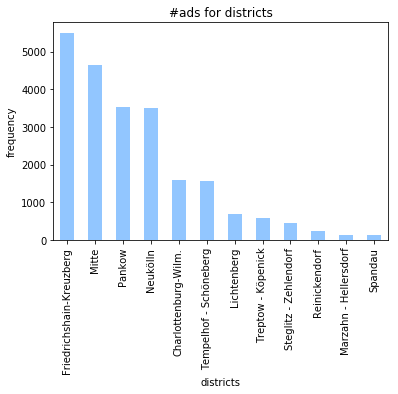

```python
berlin_data.groupby('neighbourhood_group')['neighbourhood_group']\
            .count()\
            .sort_values(ascending=False)\
            .plot(kind='bar')
plt.xlabel('districts')
plt.ylabel('frequency')
plt.title('#ads for districts')


plt.show()
```

By looking at the map of Berlin it can be noticed how the list of frequency of appearances of districts is highly related to the Berlin city geography. The list head is the neighbourhood in the centre of Berlin and, by going to the bottom, the districts that appear are the ones closer to the city centre. The last position belong to the most periferic district.

Spandau neighbourhood is the most periferic and this may be the reason why it has a less number of listings. Friedrichshain-Kreuzberg is instead a central neighbourhood and the 'coolest place' in Berlin, due to its attractivity it has the highest number of listings.

[figure not shown]

The data reported in the statistics show perfectly how the central areas of Berlin are the most choosen for listing publication, which is completely meaningful.

Here below it was reported the list of neighbourhoods mean price. It is interesting to see how the Friedrichshain-Kreuzberg is not the most expensive district. The most expensive one is Charlottenburg-Wilmersdorf

```python
berlin_data.groupby(['neighbourhood_group'])['price'].mean().sort_values(ascending=False)
```

```
neighbourhood_group
Charlottenburg-Wilm.        114.270729
Tempelhof - Schöneberg       96.572436
Mitte                        69.699417
Pankow                       67.822649
Friedrichshain-Kreuzberg     60.828816
Spandau                      58.233871
Marzahn - Hellersdorf        56.503546
Steglitz - Zehlendorf        56.327231
Lichtenberg                  56.113372
Treptow - Köpenick           52.216807
Reinickendorf                48.263158
Neukölln                     46.567305
Name: price, dtype: float64
```

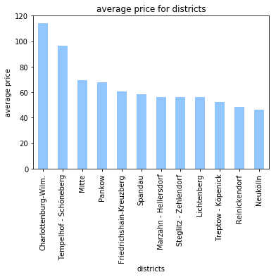

```python
berlin_data.groupby('neighbourhood_group')['price']\
.mean()\
.sort_values(ascending=False)\
.plot(kind='bar', x='districts', y='average price')
plt.xlabel('districts')
plt.ylabel('average price')
plt.title('average price for districts')
plt.show()
```

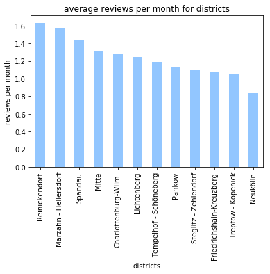

```python
berlin_data.groupby('neighbourhood_group')['reviews_per_month']\
.mean()\
.sort_values(ascending=False)\
.plot(kind='bar')
plt.xlabel('districts')
plt.ylabel('reviews per month')
plt.title('average reviews per month for districts')
plt.show()
```

### 1.4 Type of room analysis

The type of room column is another important aspect in the analysis of the Airbnb market in Berlin. The dataset presents 3 different type of rooms:

```
1. Private room (11534)
2. Entire home/apt (10722)
3. Shared room (296)
```

```python
%%capture
berlin_data['room_type'].value_counts()
```

The most frequent type is the private room. Private room means that the host makes available a part of his house to guests. This data confirms how the initial idea of the Airbnb market to allowing users to turn their apartment into a bed & breakfast is already strong. Airbnb name in fact derive from $\textit{AirBedandBreakfast}$ which suggests the initial idea. Anyway the great number of entire home/apartment indicates how the market idea is changing rapidly and move to a real home rental company.

Here below we have analyzed the total income made for each single room apartment. The results are not surprising because they denote how the price for an entire apartment is, on average, higher than the cost of a private room.

Here the total incomes available for each room type is shown.

```python
berlin_data.groupby(['room_type'])['price'].sum()
```

```
room_type
Entire home/apt    893667
Private room       605294
Shared room         15263
Name: price, dtype: int64
```

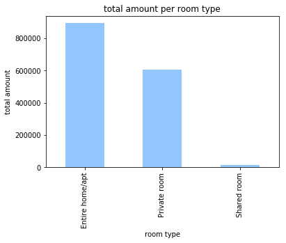

```python
berlin_data.groupby('room_type')['price']\
.sum()\
.sort_values(ascending=False)\
.plot(kind='bar')
plt.xlabel('room type')
plt.ylabel('total amount')
plt.title('total amount per room type')
plt.show()
```

Here instead the average price for each type of room is shown.

```python
berlin_data.groupby(['room_type'])['price'].mean()
```

```
room_type
Entire home/apt    83.348909
Private room       52.479105
Shared room        51.564189
Name: price, dtype: float64
```

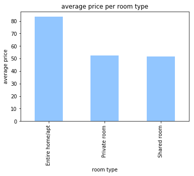

```python
berlin_data.groupby('room_type')['price']\
.mean()\
.sort_values(ascending=False)\
.plot(kind='bar')
plt.xlabel('room type')
plt.ylabel('average price')
plt.title('average price per room type')
plt.show()
```

The minimum nights columns is important to understand the relation between the room type and the requested guest category. For entire home is requested a type of guest that want to remain, on average, at least 10.45 days. Private and shared room require instead almost 3 times less with an average time of 4.18 and 3.74 respectively,

```python
berlin_data.groupby('room_type')['minimum_nights']\
.mean()
```

```
room_type
Entire home/apt    10.451035
Private room        4.182677
Shared room         3.739865
Name: minimum_nights, dtype: float64
```

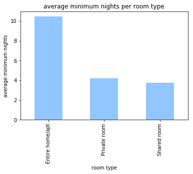

```python
berlin_data.groupby('room_type')['minimum_nights']\
.mean()\
.sort_values(ascending=False)\
.plot(kind='bar')
plt.xlabel('room type')
plt.ylabel('average minimum nights')
plt.title('average minimum nights per room type')
plt.show()
```

## 2 Data preparation

### 2.1 Unuseful columns removal

The Berlin dataset contains 16 different columns but some of them are not useful for our analysis. The only columns we need to perform market analysis are the ones related to the room type, district, price, number of reviews, reviews per month, minimum_nights, availability 365.

We will remove all the columns not useful for supervised and unsupervised techniques such as the host name, host id, latitude, logitude etc. Moreover we replace all the rows that contains a NaN with the column average value. The cleaned dataset contains the following columns:

```python
#%%capture
to_remove = ['id', 'name', 'host_id', 'host_name', 'neighbourhood', 'latitude', 'longitude', 'last_review', 'calculated_host_listings_count']
berlin_cleaned = berlin_data.drop(columns = to_remove)

#replace the NaN with the average value for that column
berlin_cleaned = berlin_cleaned.fillna(berlin_cleaned.mean())
print(berlin_cleaned.columns.values.tolist())
```

```
['neighbourhood_group', 'room_type', 'price', 'minimum_nights', 'number_of_reviews', 'reviews_per_month', 'availability_365']
```

Due to the unbalancing between the shared room and the other ones we decide to put together private and shared.  
Now that we have reduced the number of columns we have to encode the values of the columns 'room_types' and 'neighbourhood_group' into categorical data. A categoricals are a pandas data type corresponding to categorical variables in statistics. A categorical variable takes on a limited, and usually fixed, number of possible values.

```python
#remove rows containing price == 0
berlin_cleaned = berlin_cleaned[(berlin_cleaned['price'] != 0)]

# put together shared and private room (very unbalanced otherwise)
berlin_cleaned['room_type'] = berlin_cleaned['room_type'].replace('Shared room', 'Private room')
print(berlin_cleaned['room_type'].value_counts())

# pandas.factorize() encode the array values in a series of distinct int64
# Categoricals are a pandas data type corresponding to categorical variables in statistics.
# A categorical variable takes on a limited, and usually fixed, number of possible values
berlin_cleaned['neighbourhood_group'] = pd.Categorical(pd.factorize(berlin_cleaned['neighbourhood_group'])[0])
berlin_cleaned['room_type'] = pd.Categorical(pd.factorize(berlin_cleaned['room_type'])[0])

print('+Types:\n\n'+ str(berlin_cleaned.dtypes))
berlin_cleaned.head()
```

```
Private room       11825
Entire home/apt    10719
Name: room_type, dtype: int64
+Types:

neighbourhood_group    category
room_type              category
price                     int64
minimum_nights            int64
number_of_reviews         int64
reviews_per_month       float64
availability_365          int64
dtype: object
```

|  | neighbourhood_group | room_type | price | minimum_nights | number_of_reviews | reviews_per_month | availability_365 |
| --- | --- | --- | --- | --- | --- | --- | --- |
| 0 | 0 | 0 | 60 | 4 | 118 | 3.76 | 141 |
| 1 | 1 | 1 | 17 | 2 | 6 | 1.42 | 0 |
| 2 | 1 | 0 | 90 | 62 | 143 | 1.25 | 220 |
| 3 | 2 | 1 | 26 | 5 | 25 | 0.39 | 297 |
| 4 | 1 | 1 | 42 | 2 | 197 | 1.75 | 26 |

```python
display(Markdown('The final shape of the cleaned dataset is: '+ str(berlin_cleaned.shape)))
```

The final shape of the cleaned dataset is: (22544, 7)

```python
%%capture
any(berlin_cleaned['price'] == 0)
```

```python
%%capture
len(berlin_cleaned['price'])
```

### 2.2 Data standardize

In a context of multivariate analysis it is proved how the stardize operation must be done before applying any supervised or unsupervised technique, otherwise variable measured at different scales do not contribute equally to the analysis. In fact a variable that ranges between 0 and 500 will totally outweight another variable that ranges between 0 and 1. The aim of the standardize operation is to transform all the data in a comparable scale.

Tha standardize operation for a given column $\textbf{X}_k$ is the following:

$\textbf{X}_{k,std} = \frac{\textbf{X}_k - \overline{X}_k}{\sigma}$

Where $\overline{X}_k$ is the mean of the column $\textbf{X}_k$ and $\sigma$ its standard deviation. Before doing the standardization we prepare the dataset for the classification and for the regression by dividing it in two different dataset. The one for the classification have as target the room type, the one for the regression has as target the price.

```python
#preparing for regression
y_regr = berlin_cleaned['price'] #target
x_regr = berlin_cleaned.drop(columns='price') #features

#preparing for classification
y_class = berlin_cleaned['room_type'] #target
x_class = berlin_cleaned.drop(columns='room_type') #features

#remove the categorical data before make standardize
rooms_t = berlin_cleaned['room_type']
districts = berlin_cleaned['neighbourhood_group']
x_regr = x_regr.drop(columns='room_type')
x_regr = x_regr.drop(columns='neighbourhood_group')
x_class = x_class.drop(columns='neighbourhood_group')

#standardize the data
x_regr = (x_regr - x_regr.mean()) / x_regr.std()
#x_regr = StandardScaler().fit_transform(x_regr) #boring, returns a numpy.ndarray (re-build the dataframe)

x_class = (x_class - x_class.mean()) / x_class.std()
#x_class = StandardScaler().fit_transform(x_class) #boring, returns a numpy.ndarray (re-build the dataframe)

#avoid too little values
x_regr[abs(x_regr) < 1e-12] = 0
x_class[abs(x_class) < 1e-12] = 0

#avoid infinite values
x_regr.replace(np.inf, np.finfo(np.float64).max)
x_class.replace(-np.inf, -np.finfo(np.float64).max)

#add the categorical columns
x_regr['room_type'] = rooms_t
x_regr['neighbourhood_group'] = districts
x_class['neighbourhood_group'] = districts
```

Following you can see how after the standardization all the columns (except the categorical ones) have zero mean and standard deviation equal to 1.

```python
x_class.describe()
```

|  | price | minimum_nights | number_of_reviews | reviews_per_month | availability_365 |
| --- | --- | --- | --- | --- | --- |
| count | 2.254400e+04 | 2.254400e+04 | 2.254400e+04 | 2.254400e+04 | 2.254400e+04 |
| mean | 8.063399e-16 | 6.764551e-16 | 2.999441e-14 | 2.238641e-14 | 2.139267e-15 |
| std | 1.000000e+00 | 1.000000e+00 | 1.000000e+00 | 1.000000e+00 | 1.000000e+00 |
| min | -3.003495e-01 | -1.514254e-01 | -4.851960e-01 | -8.215218e-01 | -6.689478e-01 |
| 25% | -1.687118e-01 | -1.268386e-01 | -4.580025e-01 | -6.682374e-01 | -6.689478e-01 |
| 50% | -1.006234e-01 | -1.268386e-01 | -3.492285e-01 | -2.156837e-01 | -6.354375e-01 |
| 75% | 1.285739e-02 | -7.766490e-02 | -5.010002e-02 | 3.249098e-02 | 4.117595e-01 |
| max | 4.054819e+01 | 1.227581e+02 | 1.305717e+01 | 2.593754e+01 | 2.388867e+00 |

```python
%%capture
len(y_class)
```

In order to reduce the size of the column list we perform a binary encoding on the neighbourhood columns

```python
# Here perform binary encoding for neighbourhood group
dummy_regr = x_regr.drop(columns=['neighbourhood_group'])
dummy_regr = dummy_regr.reset_index(drop = True)

dummy_class = x_class.drop(columns=['neighbourhood_group'])
dummy_class = dummy_class.reset_index(drop = True)

b_vec = []
b_vec.append([0, 0, 0, 0])
b_vec.append([0, 0, 0, 1])
b_vec.append([0, 0, 1, 0])
b_vec.append([0, 0, 1, 1])
b_vec.append([0, 1, 0, 0])
b_vec.append([0, 1, 0, 1])
b_vec.append([0, 1, 1, 0])
b_vec.append([0, 1, 1, 1])
b_vec.append([1, 0, 0, 0])
b_vec.append([1, 0, 0, 1])
b_vec.append([1, 0, 1, 0])
b_vec.append([1, 0, 1, 1])


bin_neighs = []
val = []

for idx, neighs_val in enumerate(x_regr['neighbourhood_group']):
    val.append(neighs_val)
    bin_neighs.append(b_vec[neighs_val])

dummy_regr[['N_ENC1', 'N_ENC2', 'N_ENC3', 'N_ENC4']] = pd.DataFrame(bin_neighs)
dummy_regr = dummy_regr.astype({'N_ENC1': int,  'N_ENC2': int, 'N_ENC3': int, 'N_ENC4': int})

dummy_class[['N_ENC1', 'N_ENC2', 'N_ENC3', 'N_ENC4']] = pd.DataFrame(bin_neighs)
dummy_class = dummy_class.astype({'N_ENC1': int,  'N_ENC2': int, 'N_ENC3': int, 'N_ENC4': int})
```

Both the regression dataset structure and the classification dataset one are shown here below.

```python
dummy_regr.head()
```

|  | minimum_nights | number_of_reviews | reviews_per_month | availability_365 | room_type | N_ENC1 | N_ENC2 | N_ENC3 | N_ENC4 |
| --- | --- | --- | --- | --- | --- | --- | --- | --- | --- |
| 0 | -0.077665 | 2.723637 | 1.915699 | 0.512290 | 0 | 0 | 0 | 0 | 0 |
| 1 | -0.126839 | -0.322035 | 0.207673 | -0.668948 | 1 | 0 | 0 | 0 | 1 |
| 2 | 1.348371 | 3.403475 | 0.083586 | 1.174119 | 0 | 0 | 0 | 0 | 1 |
| 3 | -0.053078 | 0.194641 | -0.544150 | 1.819192 | 1 | 0 | 0 | 1 | 0 |
| 4 | -0.126839 | 4.871924 | 0.448548 | -0.451131 | 1 | 0 | 0 | 0 | 1 |

```python
dummy_class.head()
```

|  | price | minimum_nights | number_of_reviews | reviews_per_month | availability_365 | N_ENC1 | N_ENC2 | N_ENC3 | N_ENC4 |
| --- | --- | --- | --- | --- | --- | --- | --- | --- | --- |
| 0 | -0.032535 | -0.077665 | 2.723637 | 1.915699 | 0.512290 | 0 | 0 | 0 | 0 |
| 1 | -0.227722 | -0.126839 | -0.322035 | 0.207673 | -0.668948 | 0 | 0 | 0 | 1 |
| 2 | 0.103642 | 1.348371 | 3.403475 | 0.083586 | 1.174119 | 0 | 0 | 0 | 1 |
| 3 | -0.186869 | -0.053078 | 0.194641 | -0.544150 | 1.819192 | 0 | 0 | 1 | 0 |
| 4 | -0.114241 | -0.126839 | 4.871924 | 0.448548 | -0.451131 | 0 | 0 | 0 | 1 |

### 2.3 PCA

Principal component analysis (PCA) is an unsupervised technique used for dimensionality reduction for pre-processing before supervised methods and for data visualization. The dataset after the cleaning phase contains 7 different columns, if we want to represents them on a 2D scatter-plot we need to plot them 2 by 2, for an overall of $\frac{7*(7-1)}{2} = 21$ different plots.

In general if we have a matrix with $\textit{p}$ columns corresponding to $\textit{X}_1, \textit{X}_2, ..., \textit{X}_p$ features and $\textit{n}$ different rows corresponding to the observations, we need $\frac{p*(p-1)}{2}$ different subplots in order to visualize features 2 by 2. The analysis become not feasible as $\textit{p}$ increases.

PCA aims to find a low-dimensional representation of a dataset that contains as much information as possible (variance). It is based on the idea that not all the subspaces are equally interesting and so some of them can be discarded or combined together.

Each of the dimension of PCA is a linear combination of the $\textit{p}$ features. The first PC of a set of features $\textit{X}_1, \textit{X}_2, ..., \textit{X}_p$ is the normalized linear combination of the features:

$Z_1 = \phi_{11}X_1+\phi_{21}X_2+\phi_{31}X_3+...+\phi_{1p}X_p$, subject to $\sum_{j=1}^{p} \phi_{j1}^2=1$

where $\phi_1 = (\phi_{11} \phi_{21} \phi_{31} ... \phi_{p1})^T$ are the loadings which represents the direction on which the features are projected. These loading are choosen in a way that they defines a direction in the feature space along which the data vary the most. The loadings can be found by solving the following optimization problem:

$ \phi_1 = (\phi_{11} \phi_{21} \dots \phi_{p1}) : \textit{maximize} \frac{1}{n} \sum_{i=1}^{n}(\sum_{j=1}^{p}\phi_{j1}x_{ij})^2$, subject to $\sum_{j=1}^{p} \phi_{j1}^2=1$

This optimization problem can be solved both by Singular Value Decomposition (SVD) or eigenvectors extraction as we will see.

The second PC is the linear combination of $\textit{X}_1, \textit{X}_2, ..., \textit{X}_p$ that has the maximal variance among all linear combinations that are uncorrelated with $\textit{Z}_1$. Can be proved that $\textit{Z}_2$ is uncorrelated with $\textit{Z}_2$ when $\phi_2$ is orthogonal to $\phi_1$.

So at the end PCA means to find a matrix $\Phi$ such that:

$\begin{bmatrix} \phi_{11} & \phi_{12} & \phi_{13} & \dots & \phi_{1k} & \dots & \phi_{1m} \\ \phi_{21} & \phi_{22} & \phi_{23} & \dots & \phi_{2k} & \dots & \phi_{2m} \\ \dots & \dots & \dots & \dots & \dots & \dots & \dots \\ \phi_{p1} & \phi_{p2} & \phi_{p3} & \dots & \phi_{pk} & \dots & \phi_{pm} \end{bmatrix}$

where each column is the loading of a PC and all of them must be orthogonal and normal, which means that we need to find an orthonormal basis for the matrix $\textbf{X} \epsilon \mathbb{R}^{nxp}$ and so the principal component directions (the columns) $\phi_{1} \phi_{2} \phi_{3} ... \phi_{m}$ are the ordered sequence of eigenvectors of the matrix $\textbf{X}^T\textbf{X}$ and the variances of each components corresponds with its eigenvalue. There are at most $\textit{min(n-1, p)}$ principal components.

The principal components are unique except for a sign flip because since the PCs contains information about directions, the direction will be the same if the sign is changing, moreover $\textit{var(Z) = var(-Z)}$. This means that different software packages end up with the same PCs.

#### PCA using eigenvalues

- standardize the matrix
- compute the covariance matrix
- compute eigenvectors and sort them in descending order based on the value of the correspondent eigenvalue
- select the first k components

#### PCA using SVD

With the singular value decomposition of the matrix $\textbf{X}$ we obtain:

$\textbf{X} = \textbf{U} \textbf{S} \textbf{V}^T $

where

- the columns of $\textbf{U}$ represents the eigenvectors $\{\phi_1, \dots, \phi_m\}$ and can be used to reconstruct the data using linear combinations of the eigenvectors
- the matrix $\textbf{S}$ is diagonal and shows the importance of each eigenvector
- the columns of $\textbf{V}^T$ contains the coefficients for reconstructing the samples

#### How many PCs to choose?

In order to understand how many PCs its better to have we need to analyze the quantity of variance (information) each components carries with it. We are interested in knowing the Proportion of Variance Explained (PVE). By defining the total variance of the normalized (zero mean) dataset as:

$\sum_{j=1}^{p}Var(X_j) = \frac{1}{n}\sum_{j=1}^{p}\sum_{i=1}^{n}x_{ij}^2$

and the variance expressed by the m-th components as:

$\frac{1}{n}\sum_{i=1}^{n}z_{im}^2 = \frac{1}{n}\sum_{i=1}^{n}\sum_{j=1}^{p}(\phi_{jm}x_{ij})^2$

Therefore the PVE expressed by the m-th component is equal to

$\frac{\frac{1}{n}\sum_{i=1}^{n}\sum_{j=1}^{p}(\phi_{jm}x_{ij})^2}{\frac{1}{n}\sum_{j=1}^{p}\sum_{i=1}^{n}x_{ij}^2}$

The PVE is a positive number between 0 and 1. In order to compute the PVE expressed by the first $\textit{M}$ components we can just sum the PVE of each of them.

Here we analyze the number of useful PCs by displaying the PEV.

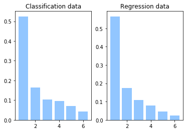

|  | PC | classification dataset | regression dataset |
| --- | --- | --- | --- |
| 1 | PC1 | 0.53 | 0.57 |
| 2 | PC2 | 0.16 | 0.18 |
| 3 | PC3 | 0.10 | 0.11 |
| 4 | PC4 | 0.09 | 0.08 |
| 5 | PC5 | 0.07 | 0.05 |
| 6 | PC6 | 0.04 | 0.02 |

```python
##### COMPUTE THE PEV


### PEV FOR CLASSIFICATION DATA:

#start computing all the PCs
pca_class = PCA()
x_class_pca = pca_class.fit_transform(x_class)

# pca.explained_variance_ratio_ returns a sorted array containing
# for each PC the variance with the respect of the total amount of variance
cvar_arr = pca_class.explained_variance_ratio_
plt.subplot(1, 2, 1)
plt.bar(np.arange(1, len(cvar_arr)+1), cvar_arr)
plt.title('Classification data')


### PEV FOR REGRESSION DATA:

#start computing all the PCs
pca_regr = PCA()
x_regr_pca = pca_regr.fit_transform(x_regr)

# pca.explained_variance_ratio_ returns a sorted array containing
# for each PC the variance with the respect of the total amount of variance
rvar_arr = pca_regr.explained_variance_ratio_
plt.subplot(1, 2, 2)
plt.bar(np.arange(1, len(rvar_arr)+1), rvar_arr)
plt.title('Regression data')

plt.show()

#compose a dataframe for displaying the PCs explained variance for both datasets
e_var = []
for idx, (cvar, rvar) in enumerate(zip(cvar_arr, rvar_arr)):
    e_var.append(['PC'+str(idx+1), cvar.round(2), rvar.round(2)])
pve_table = pd.DataFrame(e_var, columns=['PC', 'classification dataset', 'regression dataset'])
pve_table.index = pve_table.index + 1
pve_table.head(len(e_var))
```

The first 3 components of both dataset explain about the 80% of the total variance so we are going to use 3 PCs for the PCA. Here below we have reported the three scatter-plot for the regression dataset.

```python
### PCA FOR CLASSIFICATION DATA:

#start computing all the PCs
pca_class = PCA(n_components=3)
x_class_pca = pca_class.fit_transform(x_class)

### PCA FOR REGRESSION DATA:

#start computing all the PCs
pca_regr = PCA(n_components=3)
x_regr_pca = pca_regr.fit_transform(x_regr)
```

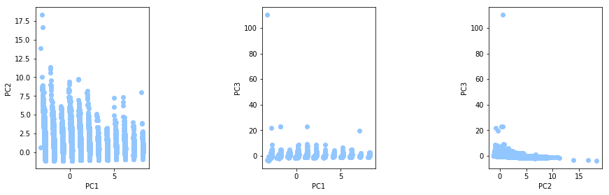

```python
# HERE PRINT SCATTER PLOT FOR PCs

plt.subplot(1, 3, 1)
plt.scatter(x_regr_pca[:, 0], x_regr_pca[:, 1])
plt.xlabel('PC1')
plt.ylabel('PC2')

plt.subplot(1, 3, 2)
plt.scatter(x_regr_pca[:, 0], x_regr_pca[:, 2])
plt.xlabel('PC1')
plt.ylabel('PC3')

plt.subplot(1, 3, 3)
plt.scatter(x_regr_pca[:, 1], x_regr_pca[:, 2])
plt.xlabel('PC2')
plt.ylabel('PC3')

plt.subplots_adjust(left  = 0.125,   # the left side of the subplots of the figure
                right = 2.0,     # the right side of the subplots of the figure
                bottom = 0.1,    # the bottom of the subplots of the figure
                top = 0.9,       # the top of the subplots of the figure
                wspace = 1.0,    # the amount of width reserved for blank space between subplots
                hspace = 0.2)   # the amount of height reserved for white space between subplots

plt.show()
```

```python
# turn it back into dataframe
x_class_pca = pd.DataFrame(x_class_pca, columns=['PC1', 'PC2', 'PC3'])
x_regr_pca = pd.DataFrame(x_regr_pca, columns=['PC1', 'PC2', 'PC3'])
```

### 3. Classification

```python
# Define the dictionary that will contain all the accuracies produced by the
# different classifier used
accuracies= {}

#Define the functions used to plot the learning curve later
# partially based on https://scikit-learn.org/stable/auto_examples/model_selection/plot_learning_curve.html
def plot_learning_curve(estimator, title, X, y, cv=None, n_jobs=-1, train_sizes=np.linspace(.1, 1.0, 5)):
    """
    Generate a simple plot of the test and training learning curve.

    Parameters
    ----------
    estimator : object type that implements the "fit" and "predict" methods
        An object of that type which is cloned for each validation.

    title : string
        Title for the chart.

    X : array-like, shape (n_samples, n_features)
        Training vector, where n_samples is the number of samples and
        n_features is the number of features.

    y : array-like, shape (n_samples) or (n_samples, n_features), optional
        Target relative to X for classification or regression;
        None for unsupervised learning.

    cv : int, cross-validation generator or an iterable, optional
        Determines the cross-validation splitting strategy.
        Possible inputs for cv are:
          - None, to use the default 3-fold cross-validation,
          - integer, to specify the number of folds.
          - :term:`CV splitter`,
          - An iterable yielding (train, test) splits as arrays of indices.

        For integer/None inputs, if ``y`` is binary or multiclass,
        :class:`StratifiedKFold` used. If the estimator is not a classifier
        or if ``y`` is neither binary nor multiclass, :class:`KFold` is used.

        Refer :ref:`User Guide <cross_validation>` for the various
        cross-validators that can be used here.

    n_jobs : int or None, optional (default=None)
        Number of jobs to run in parallel.
        ``None`` means 1 unless in a :obj:`joblib.parallel_backend` context.
        ``-1`` means using all processors. See :term:`Glossary <n_jobs>`
        for more details.

    train_sizes : array-like, shape (n_ticks,), dtype float or int
        Relative or absolute numbers of training examples that will be used to
        generate the learning curve. If the dtype is float, it is regarded as a
        fraction of the maximum size of the training set (that is determined
        by the selected validation method), i.e. it has to be within (0, 1].
        Otherwise it is interpreted as absolute sizes of the training sets.
        Note that for classification the number of samples usually have to
        be big enough to contain at least one sample from each class.
        (default: np.linspace(0.1, 1.0, 5))
    """

    train_sizes, train_scores, test_scores = learning_curve(
        estimator, X, y, cv=cv, n_jobs=n_jobs, train_sizes=train_sizes)
    train_scores_mean = np.mean(train_scores, axis=1)
    train_scores_std = np.std(train_scores, axis=1)
    test_scores_mean = np.mean(test_scores, axis=1)
    test_scores_std = np.std(test_scores, axis=1)

    plt.figure(figsize=(12,6))
    plt.fill_between(train_sizes, train_scores_mean - train_scores_std,
                     train_scores_mean + train_scores_std, alpha=0.1,
                     color="r")
    plt.fill_between(train_sizes, test_scores_mean - test_scores_std,
                     test_scores_mean + test_scores_std, alpha=0.1, color="g")
    plt.plot(train_sizes, train_scores_mean, 'o-', color="r",
             label="Training score")
    plt.plot(train_sizes, test_scores_mean, 'o-', color="g",
             label="Cross-validation score")
    plt.xlabel('#samples')
    plt.ylabel('Score')
    plt.title(title)
    plt.show()
```

### 3.1 SVM

The goal of the support vector classifier (SVC) is to find the hyperplane that separates the classes in feature space.  
First of all, we can consider the Maximal Margin Classifier:  
the hyperplane to find is a flat affine subspace, for example in 2D, it is a flat one-dimensional subspace, i.e. a line, described by:

$\beta_0 + \beta_1 \cdot X_1 + \beta_2 \cdot X_2 = 0$

In general, for a p-dimensional space, we have:

$f(x) = \beta_0 + \beta_1 \cdot X_1 + \beta_2 \cdot X_2 + ... + \beta_p \cdot X_p = $  
$ = \beta_0 + <\beta, X> = 0$

where $(\beta_0, \beta_1, ... , \beta_p)$ is called *normal vector*, that points in a direction orthogonal to the surface of a hyperplane.  
So, we can consider:

> - $f(x) < 0$ if $y_i = -1$
> - $f(x) > 0$ if $y_i = 1$
> - $f(x) = 0$ defines the separating hyperplane and $y_i \cdot f(x) > 0, \forall i$.

The classifier aims to find, between all possible hyperplane, the one that maximizes the margin *M* between two classes:

$ maximize\:M \\ subject\:to \sum_{j=1}^{p} \beta_j^2 = 1 \\ and\,y_i \cdot f(x) \geqslant M, \forall i$

But, sometimes the data are noisy, although they are separable, leading to a bad result of Maximal Margin Classifier. Then, the SVC is used to maximize a soft margin. We can add a slack variable $\epsilon$ to consider the presence of noisy points:

$ maximize\:M \\ subject\:to \sum_{j=1}^{p} \beta_j^2 = 1 \\ and\,y_i \cdot f(x) \geqslant M\cdot (1-\epsilon_i),\\\epsilon_i \geqslant 0, \sum_{i=1}^{p}\epsilon_i \leqslant C, \forall i$

where C is a regularization parameter, that tells us like "how many data would you eventually consider in the area with the higest probability of error".  
But, there are cases where the regularization is not enough, due to the distribution of samples.  
In this cases, it's possible to colve this situation by enlarging the feature space by including transformations. Fitting the SVC on this space, we will have a non-linear decision boundaries in the original space.  
To introduce the non-linearities in SVC, we can use kernels, due to the fact that it's verified the property that:

$K(x_i, x_j) = < x_i, x_j>$

We can define our linear support vector as:

$f(x) = \beta_0 + \sum_{i=1}^{p}\beta_i \cdot < x, x_i> $.

To estimate the weights $\beta_i$ and the bias term $\beta_0$, we need of all inner products between all pairs of training set.  
Then, there will be $\beta_i$ estimated, equal to 0. This means that, the only data that will matter, are the ones with $\beta_i > 0$. They are the *support vectors*, in the sense that they "support" our classification, while all the others are useless. Overall, if we can compute the inner products between all observations, we can fit the SVC, by means of kernel functions, that perform the inner product in different dimensional spaces.  
The decision function becomes:

$f(x) = \beta_0 + \sum_{i \in S}\beta_i \cdot K(x,x_i)$

Note that the summation now is for $i \in S$ to consider only the support vector, S is the set of cases where $\beta_i > 0$. Examples of kernel function:

- Polynomial: $k(x_i,x_j) = (1 + \sum_{k=1}^{p}x_{ik} \cdot x_{jk})^2$
- RBF (Radial Basis Function) = $k(x_i,x_j) = \exp{(-\gamma \cdot \sum_{k=1}^{p}(x_{ik} - x_{jk})^2)}$

Instead, briefly when there are more than two classes (k > 2) there are two possible approches:

> - OVO (if k isn't too large): One - versus - One: Fit all $\binom{k}{2}$ pairwise classifiers. Classify $x^*$ to the class that "wins" the most pairwise competition;
> - OVA: One - versus - All: Fit K different 2-class SVM classifier; each class versus the rest. Classify $x^*$ to the class for which $f_k(x)$ is largest.

```python
def my_SVM(dataset, y_class, kernel):
  # Split the dataset into train, validation and test set (5:2:3)
  x_train, x_test, y_train, y_test = train_test_split(dataset, y_class, test_size=0.3, random_state= None)
  x_train_complete = x_train # save the complete train set, before split in validation set
  y_train_complete = y_train
  # slit in validation and train sets, for further evaluation
  x_train, x_val, y_train, y_val = train_test_split(x_train, y_train, test_size=0.2, random_state= None)
  print("SVM with %s kernel" % kernel)
  print("Size dataset: %d" % len(dummy_class))
  print("Size train set: %d" % len(x_train))
  print("Size validation set: %d" % len(x_val))
  print("Size test set: %d" % len(x_test))
  #print("\nTrain set:")
  #print(x_train.head())
  #print("\t|->Labels:" + str(y_train.head()))
  #print("\t|->Number of labels: %s" % str(y_train.value_counts()))
  #print("\nValidation set:")
  #print(x_val.head())
  #print("\t|->Labels:" + str(y_val.head()))
  #print("\t|->Number of labels: %s" % str(y_val.value_counts()))
  #print("\nTest set:")
  #print(x_test.head())
  #print("\t|->Labels:" + str(y_test.head()))
  #print("\t|->Number of labels: %s" % str(y_test.value_counts()))

  # Train and test, with validation set, for evaluating the C parameter from 10^-3 to 10^3
  c_min = 10**-3
  c_max = 10**3

  accuracies = []
  accuracy_max = 0
  print("\nEvaluate SVM performace changing the C parameter")
  c = c_min
  while c <= c_max:
      print("\nTraining with C= %.3f" % c)
      classifier = svm.SVC(C = c, kernel = kernel, gamma= 'auto')
      classifier.fit(x_train, y_train) # train on train set
      print("\t|->End training\nTesting with validation set:")
      y_pred_val = classifier.predict(x_val) # evaluate on validation set
      accuracy = 100*f1_score(y_val, y_pred_val, average='binary')
      print("\t|->End testing - Accuracy= %.2f%%" % accuracy)
      accuracies.append(accuracy)
      if accuracy > accuracy_max:
          accuracy_max = accuracy
          best_c = c
      c *= 10

  for i in range(len(accuracies)):
      print("Accuracy %d : %.2f%%" % (i+1, accuracies[i]))
  print("Best C parameter is: %f with accuracy: %.2f%%" % (best_c, accuracy_max))

  # Now test the model with the test set and the best C found
  print("\nTraining with C= %.3f" % best_c)
  classifier = svm.SVC(C = best_c, kernel = kernel, gamma= 'auto')
  classifier.fit(x_train, y_train) # train on train set
  print("\t|->End training\nTesting with test set:")
  y_pred = classifier.predict(x_test) # evaluate on test set
  accuracy = 100*f1_score(y_test, y_pred, average='binary')
  print("\t|->End testing - Accuracy= %.2f%%" % accuracy)

  print("Confusion matrix:")
  print(confusion_matrix(y_test, y_pred))
  print("Classification report")
  print(classification_report(y_test, y_pred))

  return accuracy

def my_SVM_with_GridSearch(dataset, y_class, kernel):
  # Grid Search with 5-fold validation
  x_train, x_test, y_train, y_test = train_test_split(dataset, y_class, test_size=0.3, random_state= None)

  svc = svm.SVC(kernel= kernel)
  parameters = {'C':[0.001, 0.01, 0.1, 1, 10, 100, 1000],
                'gamma':[10**-11, 10**-9, 10**-7, 10**-5, 10**-3, 10**-1, 10]}
  classifier= GridSearchCV(svc, parameters, cv= 5, iid= False)
  print("SVM with %s kernel and GridSearch\nTraining..." % kernel)
  classifier.fit(x_train, y_train)
  print("End training, test:")
  y_pred = classifier.predict(x_test)
  best_c= classifier.best_params_['C']
  best_gamma= classifier.best_params_['gamma']
  best_accuracy= 100*classifier.best_score_
  print('Best parameters found in the Grid Search with 5-fold validation: ' + str(classifier.best_params_))
  print('Accuracy with these best parameters: %.2f' % best_accuracy + '%')

  # Evaluate score on the test set, with the best C and gamma values found
  accuracy = 100*f1_score(y_test, y_pred, average='binary')
  print('Accuracy on the test set with best parameters found %.2f%%' % accuracy)

  print("Confusion matrix:")
  print(confusion_matrix(y_test, y_pred))
  print("Classification report")
  print(classification_report(y_test, y_pred))
  classifier = svm.SVC(C = best_c, kernel = kernel, gamma=best_gamma)
  title = "Learning curve for SVM with " + kernel + " kernel and hyperparameters estimated with grid search"
  plot_learning_curve(classifier, title, x_train, y_train, cv=5)
  return accuracy
```

Start with defining our SVM functions.

There are two functions, which receive the dataset (samples and labels) and the desidered kernel.

In the first function, the dataset is splitted in three subsets:

> 1. Train set: to train the classifier
> 2. Validation set: to validate the parameters choosen
> 3. Test set: to test the classifier and retrieve the final accuracy.

Here the parameter estimated to achieve the best accuracy is only C. In order to do this, a set of C values are tried, using the validation set, for the test phase. When the better C value is found by the given ones, the model is already trained and tested, but this time with the test set.

Instead, the second function perform the SVM, with the given dataset and kernel, but estimating the C and gamma values, by means of GridSearch and k-fold cross-validation. This time the dataset is splitted in train and test sets, due to the fact that, the cross-validation is used.  
SVM with dataset composed by dummy variables:

```
SVM with linear kernel
Size dataset: 22544
Size train set: 12624
Size validation set: 3156
Size test set: 6764

Evaluate SVM performace changing the C parameter

Training with C= 0.001
	|->End training
Testing with validation set:
	|->End testing - Accuracy= 67.24%

Training with C= 0.010
	|->End training
Testing with validation set:
	|->End testing - Accuracy= 74.93%

Training with C= 0.100
	|->End training
Testing with validation set:
	|->End testing - Accuracy= 78.10%

Training with C= 1.000
	|->End training
Testing with validation set:
	|->End testing - Accuracy= 78.57%

Training with C= 10.000
	|->End training
Testing with validation set:
	|->End testing - Accuracy= 78.69%

Training with C= 100.000
	|->End training
Testing with validation set:
	|->End testing - Accuracy= 78.72%

Training with C= 1000.000
	|->End training
```

[output cut: 31 more lines]

```
Best parameters found in the Grid Search with 5-fold validation: {'C': 100, 'gamma': 0.1}
Accuracy with these best parameters: 79.99%
Accuracy on the test set with best parameters found 81.44%
Confusion matrix:
[[2462  792]
 [ 555 2955]]
Classification report
              precision    recall  f1-score   support

           0       0.82      0.76      0.79      3254
           1       0.79      0.84      0.81      3510

    accuracy                           0.80      6764
   macro avg       0.80      0.80      0.80      6764
weighted avg       0.80      0.80      0.80      6764
```

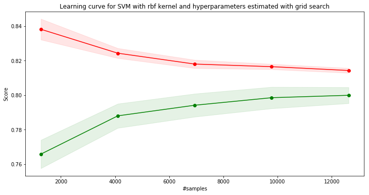

```python
#print("Dataset:")
#print(dummy_class.head())
#print("\nLabels:")
#print(y_class.head())
#print("Number of labels:\n%s" % str(y_class.value_counts()))

# Perform the svm, with linear kernel
accuracies["SVM_linear"] = my_SVM(dummy_class, y_class, 'linear')

# Perform the svm, with rbf kernel
accuracies["SVM_rbf"] = my_SVM_with_GridSearch(dummy_class, y_class, 'rbf')
```

SVM with the dataset composed by the principal components found:

```
SVM with linear kernel
Size dataset: 22544
Size train set: 12624
Size validation set: 3156
Size test set: 6764

Evaluate SVM performace changing the C parameter

Training with C= 0.001
	|->End training
Testing with validation set:
	|->End testing - Accuracy= 68.13%

Training with C= 0.010
	|->End training
Testing with validation set:
	|->End testing - Accuracy= 67.59%

Training with C= 0.100
	|->End training
Testing with validation set:
	|->End testing - Accuracy= 67.59%

Training with C= 1.000
	|->End training
Testing with validation set:
	|->End testing - Accuracy= 67.59%

Training with C= 10.000
	|->End training
Testing with validation set:
	|->End testing - Accuracy= 67.59%

Training with C= 100.000
	|->End training
Testing with validation set:
	|->End testing - Accuracy= 67.59%

Training with C= 1000.000
	|->End training
```

[output cut: 31 more lines]

```
Best parameters found in the Grid Search with 5-fold validation: {'C': 1000, 'gamma': 10}
Accuracy with these best parameters: 68.56%
Accuracy on the test set with best parameters found 71.14%
Confusion matrix:
[[2105 1124]
 [ 963 2572]]
Classification report
              precision    recall  f1-score   support

           0       0.69      0.65      0.67      3229
           1       0.70      0.73      0.71      3535

    accuracy                           0.69      6764
   macro avg       0.69      0.69      0.69      6764
weighted avg       0.69      0.69      0.69      6764
```

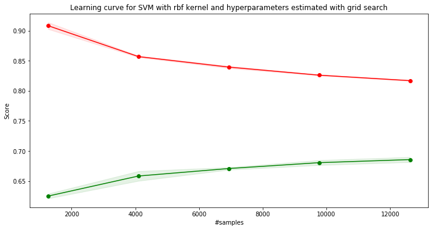

```python
#print("Dataset:")
#print(x_class_pca)
#print("\nLabels:")
#print(y_class.head())

# Perform the svm, with linear kernel
accuracies["SVM_linear_PCA"] = my_SVM(x_class_pca, y_class, 'linear')

# Perform the svm, with rbf kernel
accuracies["SVM_rbf_PCA"] = my_SVM_with_GridSearch(x_class_pca, y_class, 'rbf')
```

### 3.2 Decision Tree

The decision tree is a supervised learning algorithm used both for regression and classification tasks.  
It is based on a simple idea, for each feature in the dataset, it forms a node, using the most important attribute in the root node. So, it consists to recursive binary splitting, having a 'condition' or 'decision' that impose us if follow the left branch or the right one. The splitting continues until a leaf node is reached, which contains the outcome of the decision tree.  
To perform the binary splits there are different measures useful to choose the best attribute for the node, for example the GINI index, or the entropy.

> **GINI index**: measure of node impurity. Consider the node t:

> $ GINI(t) = 1 - \sum_{j}[p(j|t)]^2 $

> where, $p(j|t)$ is the relative frequency of class j at node t.  
> The GINI is maximum when all records are equally distribuited among all classes, this lead to an higher impurity degree; while, it is minimun (0), when all records belong the same class, producing lower impurity degree. Then, the quality of the split of the node p is computed as:

> $ GINI_{split} = \sum_{i=1}^{k}\frac{n_i}{n} \cdot GINI(i)$

> where:
> - $k$ is the number of partitions produced by the split;
> - $n_i$ is the number of records at child (partition) i;
> - $n$ is the number of records that arrives at node p.

> **Entropy:** it is another measure, that works similar to the GINI index, write as:

> $Entropy(t) = - \sum_{j}p(j|t)\cdot\log p(j|t)$

> It is maximum ($\log n_c$) when all recorcords are equally distribuited among all classes, that leads an higher impurity degree; while is minimum (0) when all records belong the same class, lower impurity degree.  
> The quality of the split of parent node p is:

> $ GAIN_{split} = Entropy(p) - \sum_{i=1}^{k}\frac{n_i}{n}\cdot Entropy(i)$

This classifier is extremely fast at classify unknown records, is easy to understand (graphically) and achieves accuracy similar to other classifier(e.g KNN) for simple dataset. The drawback is that it may be affected by missing data.  
Obviously, also for this algorithm is important to handle two problems: *underfitting* (model too simple) and *overfitting* (model too fit to the dataset used to train, it recognizes very well that kind of data, but the error respect to completely new data, is very high).  
To avoid the overfitting in the decision tree, there are two strategies:

- Pre-pruning: stop the algorithm before it becomes a fully-grown tree, with more restrictive conditions, like stop the growing if the number of instances is less than some user-specified threshold;
- Post-pruning: leave that the tree achieves its entirety dimension, so trim some node in a bottom-up fashion, and if the error improves after the trim, replace the sub-tree omitted by a leaf node.

Coming back to our case of study: start with defining our function, that performs the decision tree algorithm and plots it

```python
def my_decisionTree(dataset, y_class, max_depth):
  x_train, x_test, y_train, y_test = train_test_split(dataset, y_class, test_size=0.3, random_state= None)
  print("\nTraining with maximum depth= %d" % max_depth)
  classifier = DecisionTreeClassifier(criterion="entropy", max_depth= max_depth)
  classifier.fit(x_train, y_train) # train on train set
  print("\t|->End training\nTesting with test set:")
  y_pred = classifier.predict(x_test) # evaluate on test set
  accuracy = 100*f1_score(y_test, y_pred, average='binary')
  print("\t|->End testing - Accuracy= %.2f%%" % accuracy)
  print("Confusion matrix:")
  print(confusion_matrix(y_test, y_pred))
  print("Classification report")
  print(classification_report(y_test, y_pred))

  # Visualize decision tree
  feature_cols = dataset.columns
  dot_data = StringIO()
  export_graphviz(classifier, out_file=dot_data,
                  filled=True, rounded=True,
                  special_characters=True, feature_names = feature_cols,class_names=['0','1'])
  graph = pydotplus.graph_from_dot_data(dot_data.getvalue())
  graph.write_png('decisionTree.png')
  Image(graph.create_png())

  plt.figure(figsize = (40, 32))
  plt.imshow(plt.imread('decisionTree.png'))
  plt.axis('off');
  plt.show();

  return accuracy
```

Run the decision tree with the entire dataset, composed by dummy variables

```
Training with maximum depth= 5
	|->End training
Testing with test set:
	|->End testing - Accuracy= 80.45%
Confusion matrix:
[[2492  785]
 [ 612 2875]]
Classification report
              precision    recall  f1-score   support

           0       0.80      0.76      0.78      3277
           1       0.79      0.82      0.80      3487

    accuracy                           0.79      6764
   macro avg       0.79      0.79      0.79      6764
weighted avg       0.79      0.79      0.79      6764
```

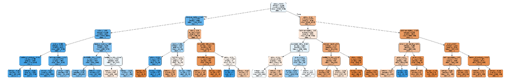

```python
#print("Dataset:")
#print(dummy_class.head())
#print("\nLabels:")
#print(y_class.head())
#print("Number of labels:\n%s" % str(y_class.value_counts()))

# Perform the decision tree with dummy variables and max depth equal to 5.
# Too lower value of max depth produces underfitting,
# while too higher produces overfitting
accuracies["DecisionTree"] = my_decisionTree(dummy_class, y_class, 5)
```

Here instead, run the algorithm with the pricipal components found by PCA

```
Training with maximum depth= 5
	|->End training
Testing with test set:
	|->End testing - Accuracy= 69.54%
Confusion matrix:
[[1823 1394]
 [ 913 2634]]
Classification report
              precision    recall  f1-score   support

           0       0.67      0.57      0.61      3217
           1       0.65      0.74      0.70      3547

    accuracy                           0.66      6764
   macro avg       0.66      0.65      0.65      6764
weighted avg       0.66      0.66      0.66      6764
```

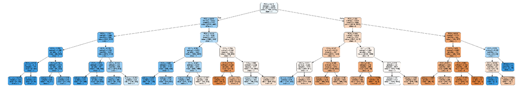

```python
#print("Dataset:")
#print(x_class_pca)
#print("\nLabels:")
#print(y_class.head())

# Perform the decision tree with principal components found by PCA
accuracies["DecisionTree_PCA"] = my_decisionTree(x_class_pca, y_class, 5)
```

### 3.3 Random Forest

The random forest algorithm works building a set of decision tree and training them on a sub-set of records of dataset randomly picked. In the case of classification, the test sample is evaluated by each tree, so it is assigned to the category that wins the majority vote, between the outcomes produced by each 'internal' classifier.

> The advantages of this algorithm are:
> - It is not biased, since there are multiple trees and each of them is tranied on a subset of samples;
> - Unlike decision tree, the random forest is not affected by missing data, and works well with categorical and numerical features

> The disadvantages instead are:
> - Requires a lot of computational resouces, due to the high number of trees joined together;
> - For the previous reason, requires more time to train w.r.t. other comparable algorithms.

In our case, first of all, we define the function to compute the random forest algorithm.  
The function *my_randomForest* receives the dataset, the labels and the number of estimators. If this one is 0, the function evaluates the performance of this classifier, among different n_estimators values. For this purpose, the dataset is split in train, test and validation set. The mechanisms is the same explained for the SVM.  
Otherwise the number of trees specified by the user is used. In this case the dataset is split only in train and test sets, the classifier is trained with the train set and then tested with the other set.  
The function returns also in this case, the accuracy achieved, and show some results, like the confusion matrix and the classification report.

```python
def my_randomForest(dataset, y_class, n_estimators):
  # Split the dataset into train, validation and test set (5:2:3)
  x_train, x_test, y_train, y_test = train_test_split(dataset, y_class, test_size=0.3, random_state= None)
  x_train_complete = x_train # save the complete train set, before split in validation set
  y_train_complete = y_train
  # slit in validation and train sets, for further evaluation
  x_train, x_val, y_train, y_val = train_test_split(x_train, y_train, test_size=0.2, random_state= None)

  # evaluate the best number of trees needed if the parameter received is 0
  if n_estimators == 0:
    number_of_trees = [10, 20, 50, 100, 1000]
    best_accuracy = 0
    for trees in number_of_trees:
      print("\nTraining random forest classifier with n_estimators= %d" % trees)
      classifier = RandomForestClassifier(n_estimators=trees, criterion="entropy")
      classifier.fit(x_train, y_train) # train on train set
      print("\t|->End training\nTesting with validation set:")
      y_pred = classifier.predict(x_val) # evaluate on validation set
      accuracy = 100*f1_score(y_val, y_pred, average='binary')
      print("\t|->End testing - Accuracy= %.2f%%" % accuracy)

      if accuracy > best_accuracy:
        best_accuracy = accuracy
        n_estimators = trees
    print("\nBest number of trees evaluated: %d" % n_estimators)
    print("---------------------------------------------------------")
    print("\nTraining random forest classifier with the best number of estimators evaluated")

  else:
    print("\nTraining random forest classifier with n_estimators= %d" % n_estimators)
  classifier = RandomForestClassifier(n_estimators=n_estimators, criterion="entropy")
  classifier.fit(x_train_complete, y_train_complete) # train on train set
  print("\t|->End training\nTesting with test set:")

  y_pred = classifier.predict(x_test) # evaluate on test set
  accuracy = 100*f1_score(y_test, y_pred, average='binary')
  print("\t|->End testing - Accuracy= %.2f%%" % accuracy)
  print("Confusion matrix:")
  print(confusion_matrix(y_test, y_pred))
  print("Classification report")
  print(classification_report(y_test, y_pred))

  return accuracy
```

Run the random forest with the entire dataset, composed by dummy variables

```python
#print("Dataset:")
#print(dummy_class.head())
#print("\nLabels:")
#print(y_class.head())
#print("Number of labels:\n%s" % str(y_class.value_counts()))

# Perform the random forest algorithm with dummy variables
accuracies["RandomForest"] = my_randomForest(dummy_class, y_class, 0)
```

```
Training random forest classifier with n_estimators= 10
	|->End training
Testing with validation set:
	|->End testing - Accuracy= 78.92%

Training random forest classifier with n_estimators= 20
	|->End training
Testing with validation set:
	|->End testing - Accuracy= 79.52%

Training random forest classifier with n_estimators= 50
	|->End training
Testing with validation set:
	|->End testing - Accuracy= 80.65%

Training random forest classifier with n_estimators= 100
	|->End training
Testing with validation set:
	|->End testing - Accuracy= 80.57%

Training random forest classifier with n_estimators= 1000
	|->End training
Testing with validation set:
	|->End testing - Accuracy= 80.74%

Best number of trees evaluated: 1000
---------------------------------------------------------

Training random forest classifier with the best number of estimators evaluated
	|->End training
Testing with test set:
	|->End testing - Accuracy= 81.33%
Confusion matrix:
[[2521  641]
 [ 694 2908]]
Classification report
              precision    recall  f1-score   support

           0       0.78      0.80      0.79      3162
           1       0.82      0.81      0.81      3602

    accuracy                           0.80      6764
   macro avg       0.80      0.80      0.80      6764
weighted avg       0.80      0.80      0.80      6764
```

Execute now, the random forest classifier, with the principal components found by the PCA

```python
# Perform the random forest algorithm with the principal components
accuracies["RandomForest_PCA"] = my_randomForest(x_class_pca, y_class, 100)
```

```
Training random forest classifier with n_estimators= 100
	|->End training
Testing with test set:
	|->End testing - Accuracy= 70.10%
Confusion matrix:
[[2233 1062]
 [1024 2445]]
Classification report
              precision    recall  f1-score   support

           0       0.69      0.68      0.68      3295
           1       0.70      0.70      0.70      3469

    accuracy                           0.69      6764
   macro avg       0.69      0.69      0.69      6764
weighted avg       0.69      0.69      0.69      6764
```

### 3.4 KNN

The K-Nearest Neighbors algorithm (KNN) is a non-parametric method, which considers the K closest training examples to the point of interest for predicting its class. This is done by a simple majority vote over the K closest points. The distance metric could be chosen from a set of possibilities, for example is common to use the Euclidean distance for continuos samples, while the Hamming distance for discrete ones.

First of all, define our KNN function, that receives the dataset, samples and labels. This function splits the dataset in train and test sets. It receives also a third parameter, for the K value:

> - if it is 0, the function searches the best k, that provides the lowest mean error, and finally train and test again the classifier, with the best K value found, evaluating the performances.
> - otherwise, train and test the classifier with the received K value.

```python
def my_KNN(dataset, y_class, k):
  # Split the dataset in train an test set
  X_train, X_test, y_train, y_test = train_test_split(dataset, y_class, test_size=0.20)

  if k == 0:
    min_error= math.inf
    best_k = 0
    errors = []
    print("Evaluate K in [1,40]... please wait!")
    # Calculating error for K values between 1 and 10 searching the best K value
    for i in range(1, 40):
      #print("Evaluate KNN with K= %d" % i)
      knn = KNeighborsClassifier(n_neighbors=i)
      knn.fit(X_train, y_train)
      pred_i = knn.predict(X_test)
      error = np.mean(pred_i != y_test)
      #print("\t|->Error= %.2f" % error)
      errors.append(error)
      if error < min_error:
        min_error = error
        best_k = i

    print("Best K= %d" % best_k)

    # Plot the error trend
    fig, ax = plt.subplots()
    ax.grid()
    fig.figsize=(12, 6)
    ax.plot(range(1, 40), errors, color='red', linestyle='dashed', marker='o',
             markerfacecolor='blue', markersize=10)
    ax.set(xlabel='K Value', ylabel='Mean Error', title='Error Rate K Value')
    plt.show()
    plt.clf()

  else:
    best_k = k

  # Perform the KNN with the best k and evaluate the results
  classifier = KNeighborsClassifier(n_neighbors=best_k)

  # Train the model with the train set
  print("Train the model with K= %d" % best_k)
  classifier.fit(X_train, y_train)

  # Test the model with the test set
  print("Evaluate the model:")
  y_pred = classifier.predict(X_test)

  # Print result of classification
  #print(y_pred)
  print("Confusion matrix:")
  print(confusion_matrix(y_test, y_pred))
  print("Classification report")
  print(classification_report(y_test, y_pred))

  accuracy = 100*f1_score(y_test, y_pred, average='binary')
  print("Accuracy: %.2f%%" % accuracy)

  classifier = KNeighborsClassifier(n_neighbors=best_k)
  title = "Learning curve for KNN with K= " + str(best_k)
  plot_learning_curve(classifier, title, X_train, y_train, cv=5)
  return accuracy
```

KNN with dataset composed by dummy variables

```
Evaluate K in [1,40]... please wait!
Best K= 16
```

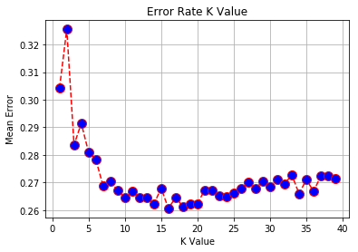

```
Train the model with K= 16
Evaluate the model:
Confusion matrix:
[[1544  606]
 [ 569 1790]]
Classification report
              precision    recall  f1-score   support

           0       0.73      0.72      0.72      2150
           1       0.75      0.76      0.75      2359

    accuracy                           0.74      4509
   macro avg       0.74      0.74      0.74      4509
weighted avg       0.74      0.74      0.74      4509

Accuracy: 75.29%
```

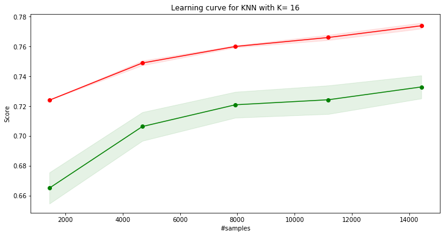

```python
#print("Dataset:")
#print(dummy_class.head())
#print("\nLabels:")
#print(y_class.head())

# Perform the knn
accuracies["KNN"] = my_KNN(dummy_class, y_class, 0)
```

KNN with dataset composed by the found principal components

```
Evaluate K in [1,40]... please wait!
Best K= 16
```

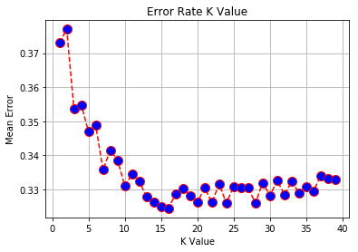

```
Train the model with K= 16
Evaluate the model:
Confusion matrix:
[[1495  646]
 [ 817 1551]]
Classification report
              precision    recall  f1-score   support

           0       0.65      0.70      0.67      2141
           1       0.71      0.65      0.68      2368

    accuracy                           0.68      4509
   macro avg       0.68      0.68      0.68      4509
weighted avg       0.68      0.68      0.68      4509

Accuracy: 67.95%
```

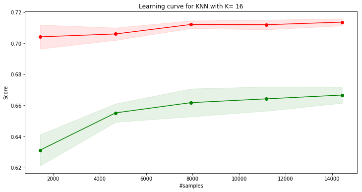

```python
#print("Dataset:")
#print(x_class_pca)
#print("\nLabels:")
#print(y_class.head())

# Perform the svm, with linear kernel
accuracies["KNN_PCA"] = my_KNN(x_class_pca, y_class, 0)
```

#### Conclusions:

Comparing the results obtained by the different classifiers:

```python
# print the accuracies obtained by the classifiers tested
for key, val in accuracies.items():
  print("%s: %.2f%%" % (key, val))
```

```
SVM_linear: 78.93%
SVM_rbf: 81.44%
SVM_linear_PCA: 69.34%
SVM_rbf_PCA: 71.14%
DecisionTree: 80.45%
DecisionTree_PCA: 69.54%
RandomForest: 81.33%
RandomForest_PCA: 70.10%
KNN: 75.29%
KNN_PCA: 67.95%
```

As we can see, the accuracies obtained by the algorithms trained with only the principal components, are much more lower w.r.t. the ones with the entire dataset. This probably may be affected by the fact that there are few features, so not enough to adopt the feature reduction with the PCA. Moreover, also the accuracies with the entire dataset are not too high, always under the 90%, so with only the principal component, it should only get worse.  
Overall, the best classifier, for our dataset, is given below:

```python
# retrieve the classifier that produces the best accuracy for our dataset
max(accuracies, key=accuracies.get)
```

```
'SVM_rbf'
```

### 4. Regression

#### 4.1 Linear regression

Linear regression is one of the most famous technique for value prediction. Differently from the classification it is used to predict real values. It is based on the assumption that there exists a linear relationship between a variable $\textit{Y}$ and a set of predictors $\textit{X}_1, \textit{X}_2, \dots, \textit{X}_p$ and it tries to model the relationship by means of this linearity, such that:

$\hat{Y} = \beta_0+\beta_1X_1+\beta_2X_2+\dots+\beta_pX_p + \varepsilon$

The values of the coefficient $\beta_j$ are choosen in a way that they minimizes the $\textit{RSS}$ ($\textit{residual sum of squares}$).

$RSS = \sum_{i=1}^{n}(y_i-\hat{y}_i)^2$

$\varepsilon$ is the error term which is a catch-all for what we miss with this simple model (non-linearity, measuring error, missing samples, missing variables..). In general we consider that $\varepsilon$ is independent of $\textit{X}$

The dataset prepared for the regression consists in 6 different features listed below.

```python
list(x_regr)
```

```
['minimum_nights',
 'number_of_reviews',
 'reviews_per_month',
 'availability_365',
 'room_type',
 'neighbourhood_group']
```

To analyze better the existing relationship between each feature and the price we have plotted several scatter-plot. In all the plots the y-axis is the log of the price because it provides a better visualization of the data (log-linear model). The first shows the relationship between price and the district, the district is figured on the x-axis (one-hot encoding) while the price is figured on the y-axis. The second plot instead (the one on the right) shows the relationship between the price and the type of the room.

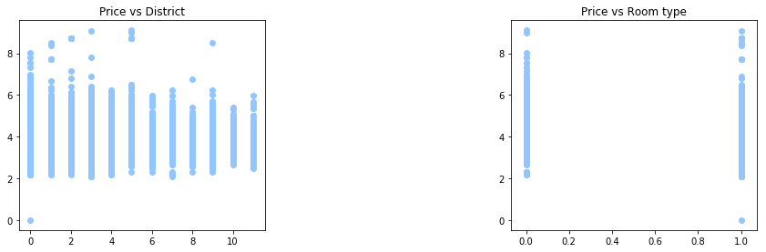

```python
plt.subplot(1, 2, 1)
plt.scatter(x=x_regr['neighbourhood_group'], y=np.log(y_regr))
plt.title('Price vs District')

plt.subplot(1, 2, 2)
plt.scatter(x=x_regr['room_type'], y=np.log(y_regr))
plt.title('Price vs Room type')

plt.subplots_adjust(left  = 0.125,   # the left side of the subplots of the figure
                right = 2.0,     # the right side of the subplots of the figure
                bottom = 0.1,    # the bottom of the subplots of the figure
                top = 0.9,       # the top of the subplots of the figure
                wspace = 1.0,    # the amount of width reserved for blank space between subplots
                hspace = 0.2)   # the amount of height reserved for white space between subplots


plt.show()
```

It can be noticed how the two features are related with the price but it cannot be enough to predict a price in an accurate way.

We will show now the relationship of price with both availability_365 and reviews. We plotted together the reviews per month and the number of reviews to understand if they similar.

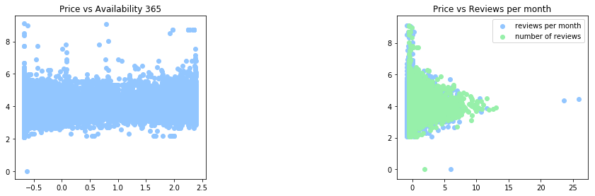

```python
plt.subplot(1, 2, 1)
plt.scatter(x=x_regr['availability_365'], y=np.log(y_regr))
plt.title('Price vs Availability 365')

plt.subplot(1, 2, 2)
plt.scatter(x=x_regr['reviews_per_month'], y=np.log(y_regr))

plt.scatter(x=x_regr['number_of_reviews'], y=np.log(y_regr))
plt.title('Price vs Reviews per month')

plt.legend(['reviews per month', 'number of reviews'])



plt.subplots_adjust(left  = 0.125,   # the left side of the subplots of the figure
                right = 2.0,     # the right side of the subplots of the figure
                bottom = 0.1,    # the bottom of the subplots of the figure
                top = 0.9,       # the top of the subplots of the figure
                wspace = 1.0,    # the amount of width reserved for blank space between subplots
                hspace = 0.2)   # the amount of height reserved for white space between subplots

plt.show()
```

In the end we analyze the relation of the price with the minimum number of nights.

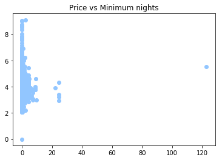

```python
plt.scatter(x=x_regr['minimum_nights'], y=np.log(y_regr))
plt.title('Price vs Minimum nights')
plt.show()
```

The plot shows a very poor relationship and for this reason we think about removing this feature from the regression analysis.

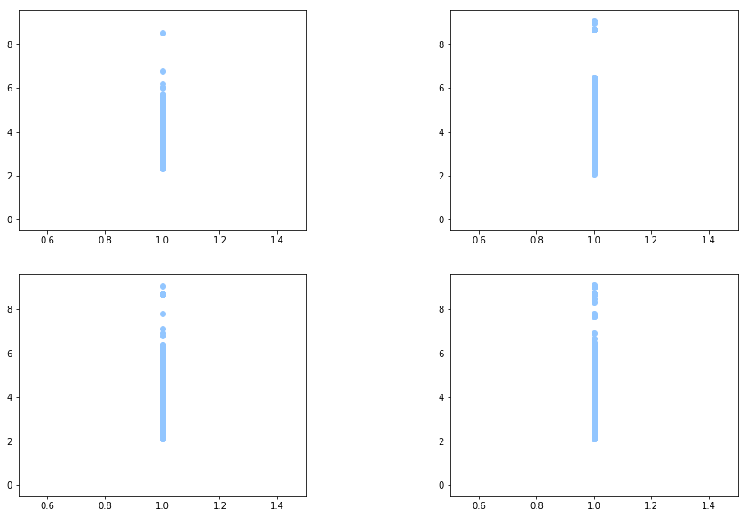

```python
y_log = np.log(y_regr)

#FIRST ROW
plt.subplot(2, 2, 1)
plt.scatter(x=dummy_regr['N_ENC1'], y=y_log)
axes = plt.gca()
axes.set_xlim([0.5,1.5])

plt.subplot(2, 2, 2)
plt.scatter(x=dummy_regr['N_ENC2'], y=y_log)
axes = plt.gca()
axes.set_xlim([0.5,1.5])

plt.subplot(2, 2, 3)
plt.scatter(x=dummy_regr['N_ENC3'], y=y_log)
axes = plt.gca()
axes.set_xlim([0.5,1.5])

plt.subplot(2, 2, 4)
plt.scatter(x=dummy_regr['N_ENC4'], y=y_log)
axes = plt.gca()
axes.set_xlim([0.5,1.5])


plt.subplots_adjust(left  = 0.125,   # the left side of the subplots of the figure
                right = 2.0,     # the right side of the subplots of the figure
                bottom = 0.1,    # the bottom of the subplots of the figure
                top = 2,       # the top of the subplots of the figure
                wspace = 0.5,    # the amount of width reserved for blank space between subplots
                hspace = 0.2)   # the amount of height reserved for white space between subplots
plt.show()
```

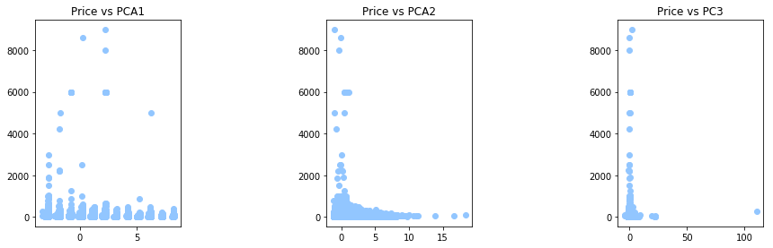

```python
plt.subplot(1, 3, 1)
plt.scatter(x=x_regr_pca['PC1'], y=y_regr)
plt.title('Price vs PCA1')

plt.subplot(1, 3, 2)
plt.scatter(x=x_regr_pca['PC2'], y=y_regr)
plt.title('Price vs PCA2')

plt.subplot(1, 3, 3)
plt.scatter(x=x_regr_pca['PC3'], y=y_regr)
plt.title('Price vs PC3')

plt.subplots_adjust(left  = 0.125,   # the left side of the subplots of the figure
                right = 2.0,     # the right side of the subplots of the figure
                bottom = 0.1,    # the bottom of the subplots of the figure
                top = 0.9,       # the top of the subplots of the figure
                wspace = 1.0,    # the amount of width reserved for blank space between subplots
                hspace = 0.2)   # the amount of height reserved for white space between subplots


plt.show()
```

#### F-statistic

Another way to understand which are the most important predictors is to test the null hypothesis $\textit{H}_0$. We can define two main hypothesis, the null and its alternative:

$H_0 : \beta_1 = \beta_2 = \beta_3 = \dots = \beta_p = 0$  
$H_a$: at least one $\beta_j$ is different from $0$

For what concern the simple linear regression the $\textit{H}_0$ verification is simpler and consists in estimate $\hat{\beta_1}$ in such a way it can guarantee that $\beta_1 \neq 0$. In this scenario the $\textit{t-statistic}$ measures the number of standard deviation that $\beta_1 \neq 0$.

$t=\frac{\hat{\beta}_1-0}{SE{\hat{\beta}_1}}$

where:

$SE({\hat{\beta}_1})^2=\frac{\sigma^2}{\sum_{i=1}^{n}(x_i-\overline{x})^2}, \sigma^2 = Var(\beta_1)$

The multiple linear regression instead require the definition of $\textit{F-statistic}$. The $\textit{F-statistic}$ is used to understand when $\textit{Y}$ is related with $\textit{X}$. The null hypothesis is performed by computing this statistic which have the following form:

**$F=\frac{\frac{TSS - RSS}{p}}{\frac{RSS}{n-p-1}}$**

When there is no relationship between response and predictors $F \approx 1$, else if $\textit{H}_a$ is true then $F > 1$.  
Another important indicator is the $\textit{p-value}$ associated with each predictors. This indicator can be seen as the probability of that predictor to be zero (thus verifying the $\textit{H}_0$ hypothesis), so higher is the value, smaller is the statistic meaning of this predictors. Tipically a predictors can be omitted from the analysis if its $\textit{p-value}$ is higher than a certa threshold $\alpha$ (e.g. $\alpha = 0.05$)

```python
x = dummy_regr
y = np.log(y_regr)

regr_model = feature_selection.SelectKBest(score_func=feature_selection.f_regression, k=4)
results = regr_model.fit(x, y)

rows = []

for h, (scr, pval) in zip(list(dummy_regr), zip(results.scores_, results.pvalues_)):
    rows.append([h, str(scr), str(pval)])

f_table = pd.DataFrame(rows, columns=['Features', 'F-score', 'p-value'])
f_table.head(len(f_table))
```

|  | Features | F-score | p-value |
| --- | --- | --- | --- |
| 0 | minimum_nights | 6.842303004037598 | 0.008908331716296203 |
| 1 | number_of_reviews | 172.95435651220535 | 2.338496309158515e-39 |
| 2 | reviews_per_month | 97.3172879793509 | 6.572439623093815e-23 |
| 3 | availability_365 | 1458.2265523148346 | 3.19210980610401e-309 |
| 4 | room_type | 8765.815905929134 | 0.0 |
| 5 | N_ENC1 | 95.38414845836509 | 1.7376735793777838e-22 |
| 6 | N_ENC2 | 181.05021533772486 | 4.1199553928334847e-41 |
| 7 | N_ENC3 | 0.009977107575244351 | 0.9204361383393853 |
| 8 | N_ENC4 | 101.49420594611232 | 8.049928288711765e-24 |

```python
f1_remove = ['N_ENC3']
```

#### Accuracy

The accuracy of regression model should be an indicator of how good the model fits the data. There are two main ways for evaluating the accuracy of a regression model:

```
* Residual standard error (RSE)
* R-squared
```

The RSE is an estimate of the standard deviation of $\varepsilon$, so it is the average amount that the response will deviate from the true regression line. A good model should have a RSE that tends to be 0.

$RSE = \sqrt{\frac{1}{n-2}RSS} = \sqrt{\frac{1}{n-2}\sum_{i=1}^{n}(y_i - \hat{y}_i)^2}$

Because of the RSE is measured in the units of $\textit{Y}$ it is not always clear what constitutes a good value for the RSE.  
The $\textit{R-squared}$ provides an alternative statistic and it takes the form of a proportion of the variance explained, so independent of the scale of $\textit{Y}$.

$R^2 = \frac{TSS-RSS}{TSS} = 1 - \frac{RSS}{TSS}$

where

$TSS = \sum_{i=1}^{n}(y_i - \overline{y}_i)^2$

$\textit{TSS}$: amount of variability inherent in the response before the regression is applied.  
$\textit{RSS}$: amount of variability that is left unexplained after performing the regression.  
$\textit{TSS-RSS}$: amount of variability in the response that is explained by performing the regression.  
So the $\textit{R-squared}$ measures the proportion of variability in $\textit{Y}$ that can be explained using $\textit{Y}$. It is a value $\epsilon$ $[0, 1]$ where a low $\textit{R-squared}$ means a wrong model or a high error (or both).

Values for the $\textit{R-squared}$ of the regression with all the features:

```python
X = dummy_regr
Y = np.log(y_regr)
kfold = KFold(n_splits=2, shuffle=True, random_state=_SEED)
#regr_model = Ridge(alpha=.5)
regr_model = LinearRegression()
#regr_model = SVR(kernel='poly', C=1e3, gamma=0.1)

scores = []

for idx, (train, test) in enumerate(kfold.split(X, Y)):
    #print(X.iloc[train, [4, 5]])
    regr_model.fit(X.iloc[train, :], Y.iloc[train])
    score = regr_model.score(X.iloc[test, :], Y.iloc[test])
    scores.append(score)

print(scores)
```

```
[0.30269212261418543, 0.3297655794801727]
```

Values for the $\textit{R-squared}$ of the regression removing minimum nights and the number of reviews:

```python
X = dummy_regr.drop(columns=['minimum_nights', 'number_of_reviews'])
Y = np.log(y_regr)
kfold = KFold(n_splits=2, shuffle=True, random_state=_SEED)
#regr_model = Ridge(alpha=.5)
regr_model = LinearRegression()
#regr_model = SVR(kernel='poly', C=1e3, gamma=0.1)

scores = []

for idx, (train, test) in enumerate(kfold.split(X, Y)):
    #print(X.iloc[train, [4, 5]])
    regr_model.fit(X.iloc[train, :], Y.iloc[train])
    score = regr_model.score(X.iloc[test, :], Y.iloc[test])
    scores.append(score)

print(scores)
```

```
[0.3368290001364227, 0.32822206712517166]
```

Values for the $\textit{R-squared}$ of the regression removing the columns with higher $\textit{p-values}$:

```python
X = dummy_regr.drop(columns=f1_remove)
Y = np.log(y_regr)
kfold = KFold(n_splits=2, shuffle=True, random_state=_SEED)
#regr_model = Ridge(alpha=.5)
regr_model = LinearRegression()
#regr_model = SVR(kernel='poly', C=1e3, gamma=0.1)

scores = []

for idx, (train, test) in enumerate(kfold.split(X, Y)):
    #print(X.iloc[train, [4, 5]])
    regr_model.fit(X.iloc[train, :], Y.iloc[train])
    score = regr_model.score(X.iloc[test, :], Y.iloc[test])
    scores.append(score)

print(scores)
```

```
[0.3021077058698961, 0.32935931793066175]
```

Values for the $\textit{R-squared}$ of the regression removing the columns minimum nights, number of reviews and the ones with higher $\textit{p-values}$:

```python
to_remove = ['minimum_nights', 'number_of_reviews']
to_remove += f1_remove
X = dummy_regr.drop(columns=to_remove)
Y = np.log(y_regr)
kfold = KFold(n_splits=2, shuffle=True, random_state=_SEED)
#regr_model = Ridge(alpha=.5)
regr_model = LinearRegression()
#regr_model = SVR(kernel='poly', C=1e3, gamma=0.1)

scores = []

for idx, (train, test) in enumerate(kfold.split(X, Y)):
    #print(X.iloc[train, [4, 5]])
    regr_model.fit(X.iloc[train, :], Y.iloc[train])
    score = regr_model.score(X.iloc[test, :], Y.iloc[test])
    scores.append(score)

print(scores)
```

```
[0.33597838198969276, 0.3278668922578858]
```

#### 4.2 Regression tree

Another important technique to perform regression is to use tree-based methods. These methods provide great explainability but generally worse accuracy than other supervised algorithms.  
The main idea is to divide the feature space composed by $X_1,X_2,\dots,X_j$ in $J$ different and non overlapping sub-regions $R_1,R_2,\dots,R_j$. This procedure creates a tree which, starting from the root, expands in different branches representing the cutting-point for the sub-regions up to the final leaves that represents each single sub-region $R_i$. For every observation that falls inside sub-region $R_i$, the response will be the average of all the responses of each training observation that fell inside the region.  
How to find the regions $R_1,R_2,\dots,R_j$ ?  
Let's find $J$ regions that minimizes the $RSS$:

$RSS = \sum_{j=1}^{J}\sum_{i\epsilon R_j}(y_i - \hat{y}_{R_j})^2$

The problem of finding all the possible $J$ partition of the feature space that minimizes the $RSS$ is unfeasible, so a top-down greedy approach called $\textit{recursive binary splitting}$ has to be used. The approach is greedy because we decide each cutting point withouth taking in consideration future steps and top-down because we start from the root of the tree. At first step we choose among $p$ feature predictors and cutting point for each features, the predictor $X_i$ and the cutting point $s$ so that splitting the predictor space into regions $\{X|X_j<s\}$ and $\{X|X_j\geqslant s\}$ lead to the greates possible reduction in $RSS$.  
Writing down some equations we search the subspaces $R_1$ and $R_2$ in such a way they minimize the $RSS$:

$\sum_{i:x_i\epsilon R_1(j,s)}(y_i-\hat{y}_{R_1})^2+\sum_{i:x_i\epsilon R_2(j,s)}(y_i-\hat{y}_{R_2})^2$

Where the values $\hat{y}_{R_1}$ and $\hat{y}_{R_2}$ are the mean responses for the training observation respectively in $R_1$ and $R_2$. In next step we choose the predictors not among all the initial features but among $p-1$ features. We continue this process until a stopping criterion is reached, for instance when each subspace contains no more than $k$ examples.

#### Tree pruning:

The $\textit{recursive binary splitting}$ often lead to very complex tree that overfits the training data. In order to avoid that we should take in consideration a smaller tree by means of a pruning technique. We will describe in this section the $\textit{cost complexity pruning}$.  
Cost complexity pruning consists in choosing a sequence of trees from the original one, each one indexed by a nonnegative tuning parameter $\alpha$. We perform cross validation to choose the best value of $\alpha$ and then choose the correspondent pruned tree. For each value of $\alpha$ we search for the tree that minizes the following equation:

$\sum_{m=1}^{\|T\|}\sum_{i:x_i\epsilon R_m}(y_i-\hat{y}_{R_m})^2+\alpha \|T\|$

Where $\|T\|$ is the number of terminal nodes of the tree.  
The above equation is a trade off between the tree complexity and its fit to the training data. When $\alpha$ is high we penalize more the complex trees, but we always take care about the $RSS$ of the tree. With cross-validation we can tune $\alpha$ and return the tree that minimizes the above quantityò.

```python
t_regr = DecisionTreeRegressor(max_depth=10)
X = dummy_regr
Y = np.log(y_regr)
kfold = KFold(n_splits=10, shuffle=True, random_state=_SEED)

scores = []

for idx, (train, test) in enumerate(kfold.split(X, Y)):
    #print(X.iloc[train, [4, 5]])
    t_regr.fit(X.iloc[train, :], Y.iloc[train])
    score = t_regr.score(X.iloc[test, :], Y.iloc[test])
    scores.append(score)

print(scores)


# Visualize decision tree
#feature_cols = X.columns
#dot_data = StringIO()
#export_graphviz(t_regr, out_file=dot_data,
#              filled=True, rounded=True,
#              special_characters=True, feature_names = feature_cols,class_names=['0','1'])
#graph = pydotplus.graph_from_dot_data(dot_data.getvalue())
#graph.write_png('decisionTree_regr.png')
#Image(graph.create_png())

#plt.figure(figsize = (40, 32))
#plt.imshow(plt.imread('decisionTree_regr.png'))
#plt.axis('off');
#plt.show();
```

```
[0.3350091186959956, 0.3909546350425851, 0.3865574329049406, 0.35933828285342284, 0.32682090360167226, 0.28420791364657183, 0.30062054134915495, 0.33402847960684856, 0.3613931460099902, 0.33237776606698644]
```

#### 4.3 Random forests regression

The $R^2$ scores for the decision tree regressor above were very poor. Another possibility is to build more than one single tree and then take as response the average of responses for each tree.  
$\textit{Bagging}$ consists in build different trees and fit each of them onto a set of data created by bootstrapping the training set. We then train $B$ different regressor trees and take as response the average response of trees, in this way we reduce the variance.

$\hat{f}_{avg}(x) = \frac{1}{B}\sum_{b=1}^{B}\hat{f}^b(x)$

$\textit{Random forests}$ is instead a technique which also try to decorrelates the builded trees. The main idea is that each tree of a bagging will have some strong predictors and other weak ones, so each tree will take as first split always the stronger ones, make them correlated to each others. In order to avoid that, $\textit{Random forests}$ decide at each step among $m$ out of $p$ randomly selected predictors for the split, tipically $m=\sqrt{p}$.  
Here below we have applied $\textit{Random forests}$ with 1000 and 100 different trees an it can be noticed how $R^2$ scores are slightly better with the respect to both single regressor tree and linear regression, even if they still miss some important predictors.

```python
num_trees = 1000
rf = RandomForestRegressor(n_estimators = num_trees, random_state = 42)
X = dummy_regr
Y = np.log(y_regr)
kfold = KFold(n_splits=10, shuffle=True, random_state=_SEED)

scores = []

for idx, (train, test) in enumerate(kfold.split(X, Y)):
    #print(X.iloc[train, [4, 5]])
    rf.fit(X.iloc[train, :], Y.iloc[train])
    score = rf.score(X.iloc[test, :], Y.iloc[test])
    scores.append(score)

print('number of trees: '+str(num_trees))
print(scores)
```

```
number of trees: 1000
[0.37695859007732146, 0.3972160587215342, 0.4279100583149291, 0.3864065021738444, 0.37294313048881955, 0.3324376081709228, 0.3213243493010103, 0.36235617125238484, 0.4042207423969807, 0.36669453868813695]
```

```python
num_trees = 100
rf = RandomForestRegressor(n_estimators = num_trees, random_state = 42)
X = dummy_regr
Y = np.log(y_regr)
kfold = KFold(n_splits=10, shuffle=True, random_state=_SEED)

scores = []

for idx, (train, test) in enumerate(kfold.split(X, Y)):
    #print(X.iloc[train, [4, 5]])
    rf.fit(X.iloc[train, :], Y.iloc[train])
    score = rf.score(X.iloc[test, :], Y.iloc[test])
    scores.append(score)

print('number of trees: '+str(num_trees))
print(scores)
```

```
number of trees: 100
[0.37300668906220624, 0.394044016762622, 0.42572109055588914, 0.38313961630205023, 0.3635867118453219, 0.32707973715314975, 0.31805365544819464, 0.35816924906897585, 0.397619675688992, 0.3643853599666672]
```

#### Conclusions:

We have performed regression on the Berlin-Airbnb dataset in order to predict the price of each ads on the listings. The most powerful technique we have found for such a task was the $\textit{Random forests}$ with 1000 different trees.  
Regarding the regression, unfortunately results were very poor but we do not think that our model was wrong. What we think is that the price of the house is for sure related with the district and the type of room but, some important missing features, such as the house size, the furniture, the presence of a balcony or a garden are the main discriminants to predict the price of a house. For this reason we conclude our prediction analysis asserting that this type of dataset is not so useful for such a task.

### 5. Final considerations

We have performed classification and regression on the Berlin AirBnb dataset of 2018. The results are quite good for the classification task whose goal is to predict the correct type of room given the other features.  
The regression instead aims to predict the price of the house given other features like neighbourhood and type of room. In this work the results are quite bad but we are conscious that the dataset is not ideal for this type of task as we have already assert.